# Introduction à l’intelligence artificielle

## Classification d’images

### Discriminer les chiffres MNIST (LeCun, Boser, J. Denker, et al. 1989; LeCun, Boser, J. S. Denker, et al. 1989; LeCun et al. 1998)

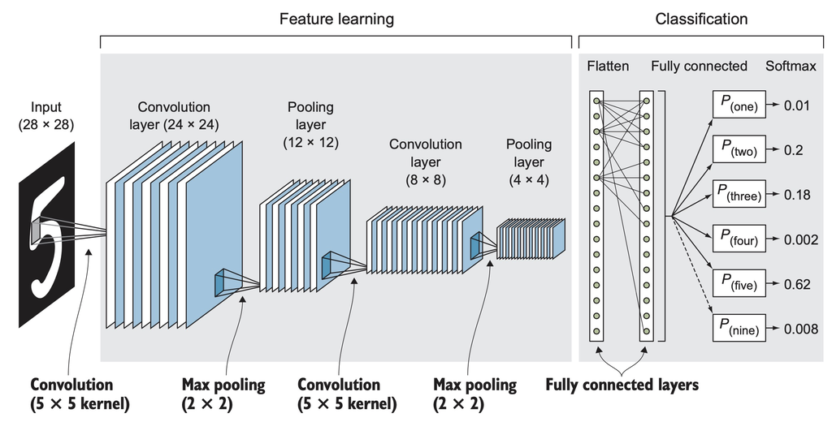

Source : (Elgendy 2020)

## Classification d’images

### Discriminer les chiffres MNIST

[video not shown]

Source : [3blue1brown](https://www.youtube.com/watch?v=aircAruvnKk)

## Deep learning

### AlexNet (Krizhevsky et al. 2012)

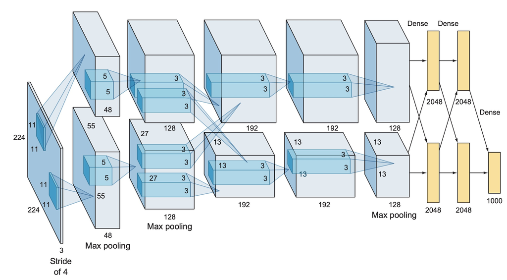

Source : (Elgendy 2020)

## Deep learning

### La première couche du réseau

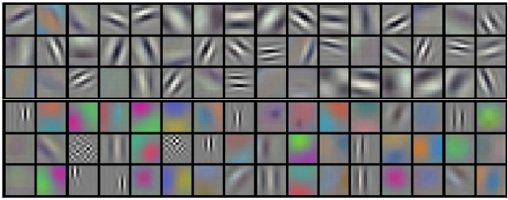

Source : (Krizhevsky et al. 2012)

## Deep learning

### Les couches du réseau extraient des features à différentes échelles

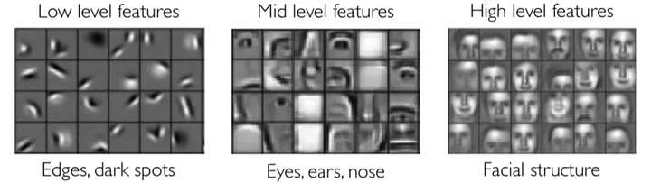

Source : [Medium](https://medium.com/sysinfo/convolutional-neural-network-1c8c1d7e0707)

## Deep learning

### Les couches du réseau extraient des features à différentes échelles

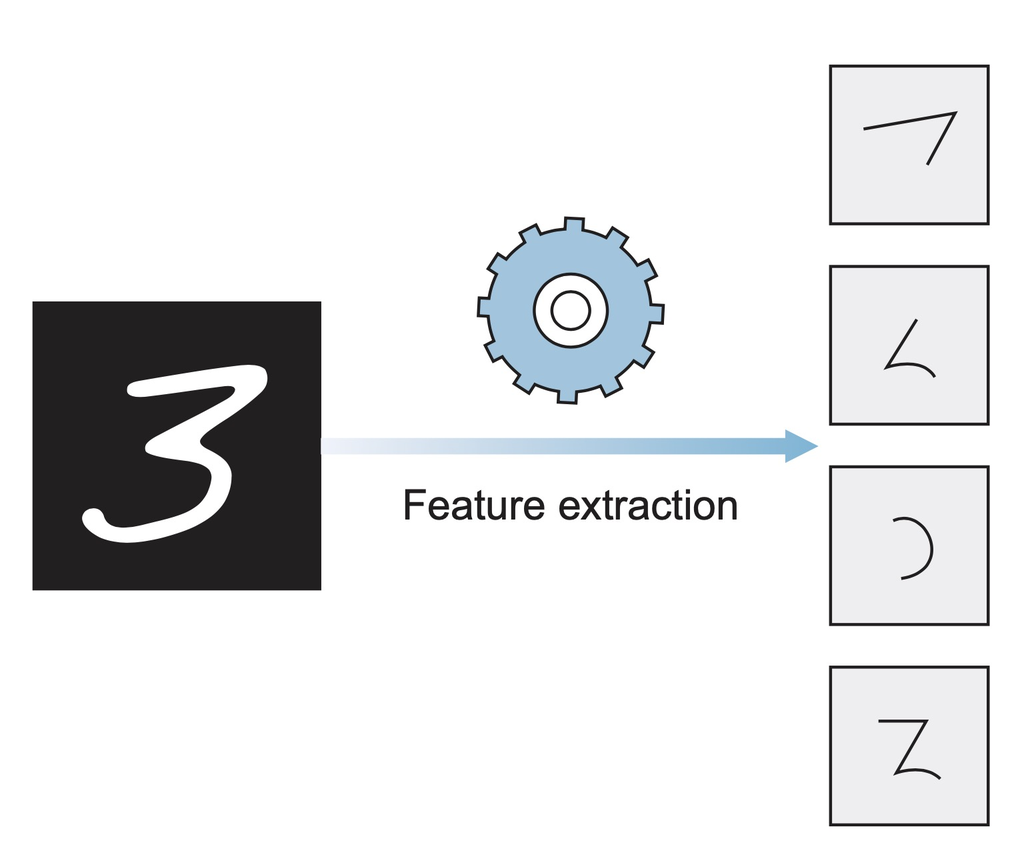

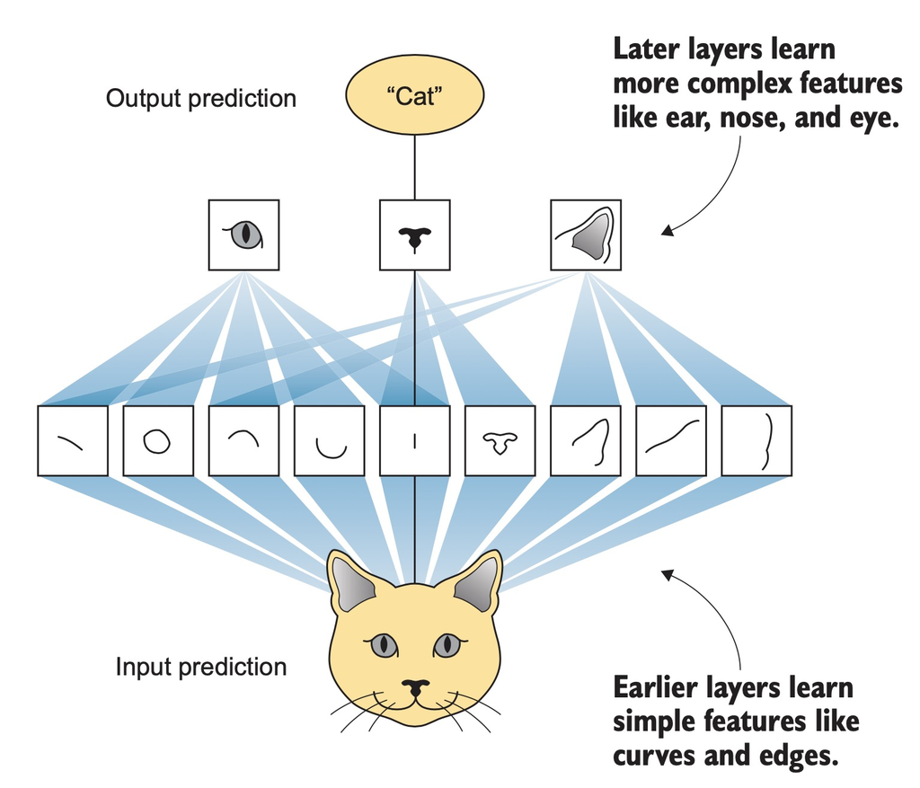

Source : (Elgendy 2020)

## Deep learning

### Les couches du réseau extraient des features à différentes échelles

[video not shown]

Source : [3blue1brown](https://www.youtube.com/watch?v=aircAruvnKk)

## Deep learning

### Les CNN en résumé

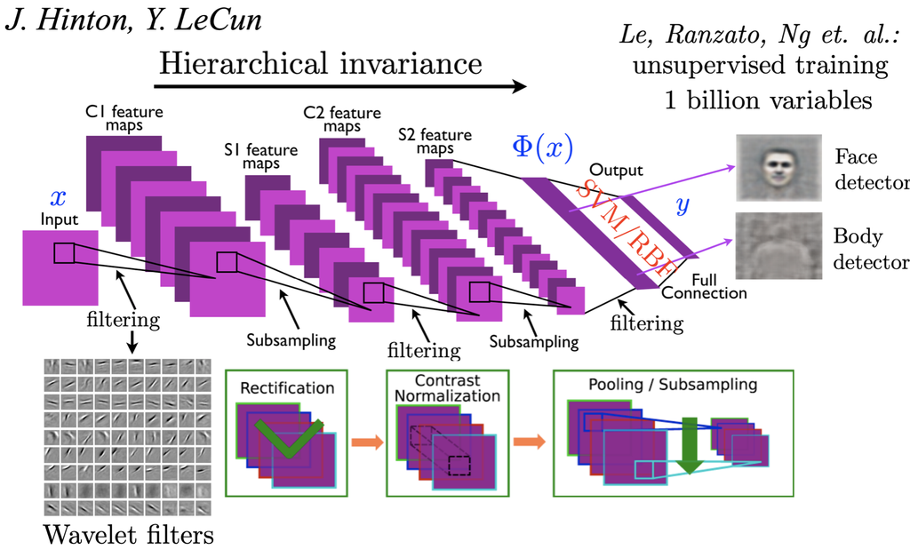

Source : (Maried et al. 2017)

## Deep learning

### AlexNet *breakthrough*

[video not shown]

Source : [Welch Labs](https://www.youtube.com/watch?v=UZDiGooFs54)

## Deep learning

### Un déluge de données

- 1,2 millions d’images d’entrainement
- 100 000 images de test

[figure not shown]

Source : [Andrej Karpathy](https://cs.stanford.edu/people/karpathy/cnnembed/)

## Deep learning

### 1000 classes d’objets dans ImageNet

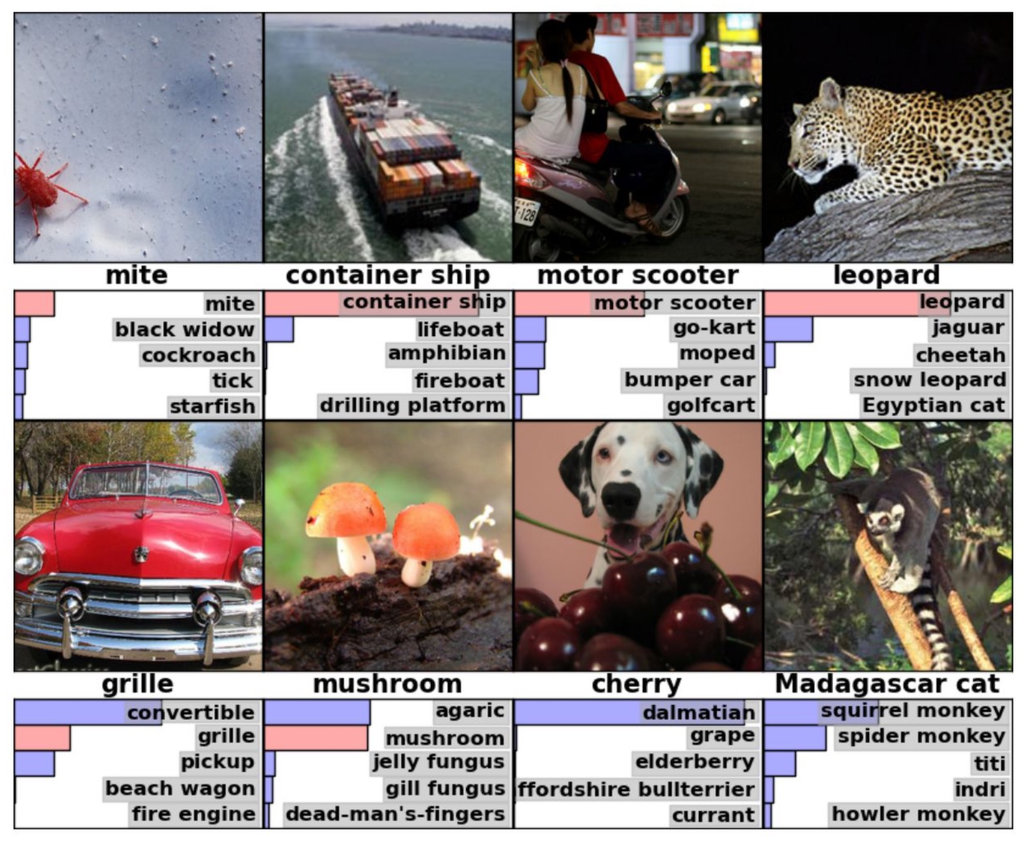

Source : (Krizhevsky et al. 2012)

## Deep learning

### Le succès des CNN en classification d’images

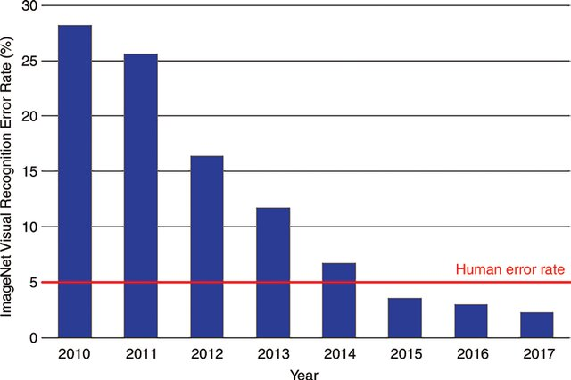

Source : (Allen et al. 2019)

## Deep learning

### L’une des raisons de ce succès : les ressouces computationnelles

[figure not shown]

Source : [Welch Labs](https://www.youtube.com/watch?v=UZDiGooFs54)

## Qui suis-je ?

### Un esprit visionnaire sur les potentialités des machines

*“Again, it might act upon other things besides number, were objects found whose mutual fundamental relations could be expressed by those of the abstract science of operations, and which should be also susceptible of adaptations to the action of the operating notation and mechanism of the engine. Supposing, for instance, that the fundamental relations of pitched sounds in the science of harmony and of musical composition were susceptible of such expression and adaptations, the engine might compose elaborate and scientific pieces of music of any degree of complexity or extent”*

**A.L.L**

Source : [Sketch of the analytical engine](https://www.fourmilab.ch/babbage/sketch.html)

## Ada Lovelace

### L’enchanteresse des nombres

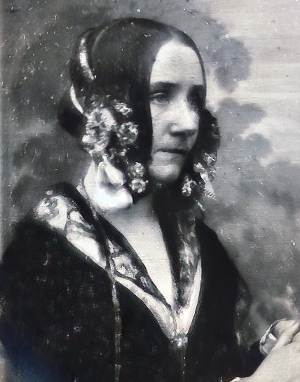

- 1815 - Naissance d’Ada Lovelace à Londres, fille du poète Lord Byron et d’Anne Isabella Milbanke.
- 1833 - Rencontre avec Charles Babbage, mathématicien et inventeur de la machine analytique.
- 1842-1843 - Publication des Notes, ajoutées à la traduction d’un article du mathématicien italien Luigi Menabrea.
- 1852 - Décès à l’âge de 36 ans, des suites d’un cancer.

Source : [Wikipédia](https://en.wikipedia.org/wiki/Ada_Lovelace)

# Conclusion

## Modélisation des neurones

### Neurones biologiques vs neurones artificiels

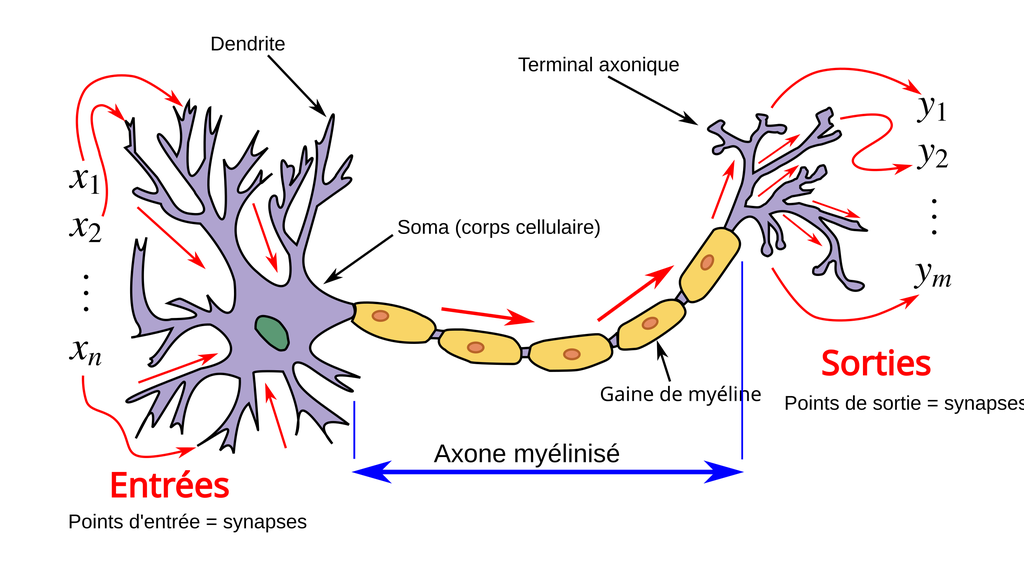

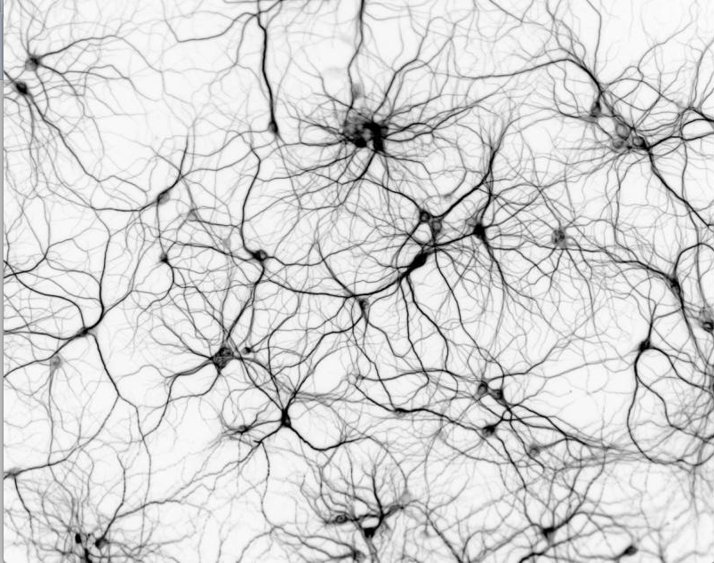

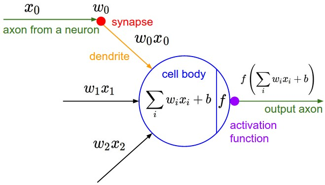

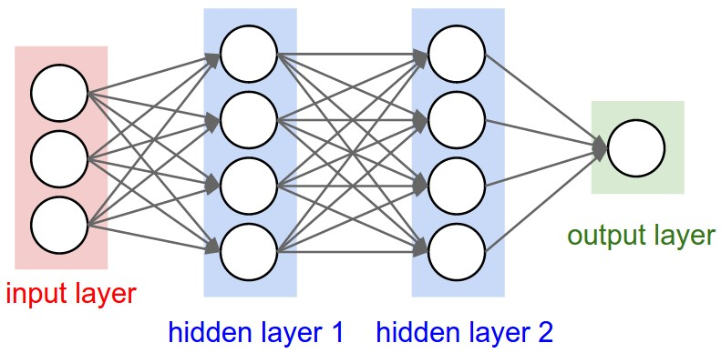

Source : [AquaPortail](https://www.aquaportail.com/dictionnaire/definition/4738/neurone) - [CS231n](https://cs231n.github.io/convolutional-networks/)

## Modélisation des réseaux de neurones

### Les CNN inspirés du fonctionnement du cortex visuel (Hubel and Wiesel 1962)

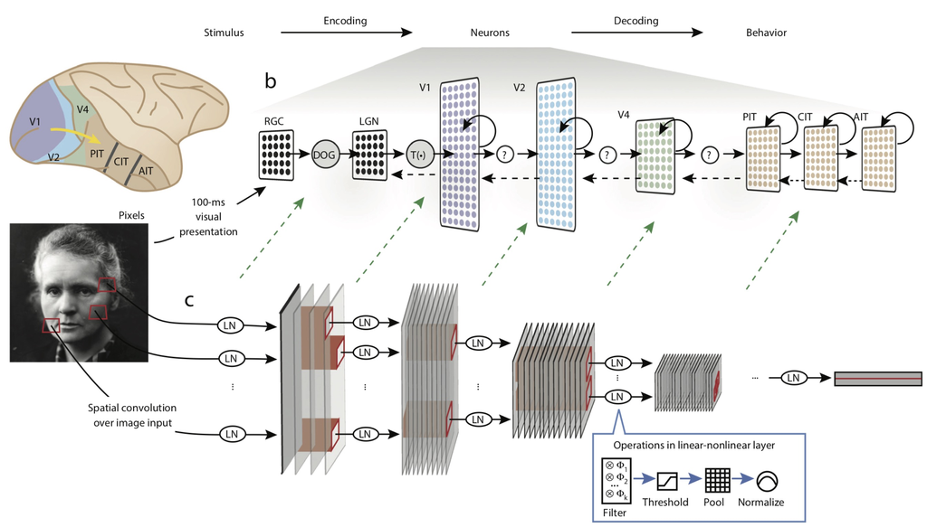

Source : (Yamins and DiCarlo 2016)

## Modélisation bio-inspirée

### L’oiseau vs l’avion

*“L’analogie peut être faite avec les pionniers de l’aviation, dont certains essayaient de reproduire les oiseaux ou les chauve-souris. Mais ils collaient un peu trop près à la biologie, comme Clément Ader. Ses travaux n’ont pas eu beaucoup de suites parce qu’il copiait les chauve-souris sans s’occuper de problèmes comme la stabilité. Alors que d’autres personnes plus proches des techniques d’ingénierie ont fait des expérimentations en soufflerie, ont essayé plusieurs profils d’ailes, etc. Et à la fin, ils ont obtenu un artefact, un avion, qui utilise les mêmes principes que les oiseaux pour voler mais dont les détails sont très différents. C’est un peu ce qu’on fait avec l’intelligence artificielle, on prend de l’inspiration avec ce qu’on observe dans le monde animal, mais on en dégage surtout des principes. On fabrique une machine dont le fonctionnement est finalement très différent de la biologie.”*

**Yann Lecun**

Source : [Telescopemag](https://telescopemag.fr/yann-le-cun-le-mythe-de-la-machine-sans-emotion-est-faux/)

## L’IA, pour quoi faire ?

### Exemples d’applications vertueuses

**Environnementales**

- Smart grids
- Optimisation des transports, éclairage, chauffage, tri des déchêts, …
- Gestion de la production agricole, images aériennes, …
- Prévoir les pics de pollution de l’air, feux de forêt, séismes, …
- Conception de matériaux / habitats plus performants
- Optimisation du couvert végétal des villes
- Modélisation du changement climatique, des écosystèmes, etc

Source : [cese](https://www.lecese.fr/sites/default/files/pdf/Avis/2024/2024_14_IA_Environnement.pdf)

## L’IA, pour quoi faire ?

### Exemples d’applications vertueuses

**Sociales et sanitaires**

- Accompagnement des personnes en situation de handicap
- Amélioration de la productivité
- Détection de maladies, chirurgie assistée par ordinateur
- Médecine préventive et personnalisée
- Fouille de données génétiques
- Prédiction de la forme des protéines
- Production de médicaments, vaccins, pharmacovigilance, …

Source : [cese](https://www.lecese.fr/sites/default/files/pdf/Avis/2024/2024_14_IA_Environnement.pdf)

## Les problèmes que posent l’IA

### Un pharmakon

- Production massive de fausses informations, algorithmes de recommandations publicitaires, *deep fakes*, …
- Reproduction de biais, application dans la justice
- Risques démocratiques : ciblages personnalisés lors des élections, hameçonnage, …
- Dépendance technologique
- Chômage structurel (?)
- Cyberattaques
- Surveillance de masse
- Drônes et autres armes autonomes

Source : [cese](https://www.lecese.fr/sites/default/files/pdf/Avis/2024/2024_14_IA_Environnement.pdf)

## Les problèmes que posent l’IA

### Une consommation considérable de ressources

- Phase d’entraînement (GPT-3) estimée à 552 tonnes CO2eq sur quinze jours (environ 200 allers-retours entre Paris et New York)
- Phase d’utilisation encore plus énergivore en volume (180 millions d’utilisateur de ChatGPT), IoT (100 milliards d’objets connectés)
- Google (14 MT CO2, +48% en 2023) : *«À mesure que nous intégrons l’IA dans nos produits, la réduction des émissions pourrait s’avérer difficile»*
- Utilisation de métaux rares, production de puces, GPU, data centers, …
- Consommation d’eau importante (le projet de data center de Meta à Talavera de la Reina, en Espagne, devrait prélever 665 millions de litres d’eau par an dans une région en plein stress hydrique).
- **Effets rebonds** (!)

Source : [cese](https://www.lecese.fr/sites/default/files/pdf/Avis/2024/2024_14_IA_Environnement.pdf)

# Des questions ?

## Bibliographie

Allen, Bibb, Steven Seltzer, Curtis Langlotz, et al. 2019. “A Road Map for Translational Research on Artificial Intelligence in Medical Imaging: From the 2018 National Institutes of Health/RSNA/ACR/the Academy Workshop.” *Journal of the American College of Radiology* 16 (May). https://doi.org/10.1016/j.jacr.2019.04.014.

Bishop, Christopher M. 2006. “Pattern Recognition and Machine Learning.” *Springer Google Schola* 2: 1122–28.

Elgendy, Mohamed. 2020. *Deep Learning for Vision Systems*. Simon; Schuster.

Hubel, David H, and Torsten N Wiesel. 1962. “Receptive Fields, Binocular Interaction and Functional Architecture in the Cat’s Visual Cortex.” *The Journal of Physiology* 160 (1): 106.

Krizhevsky, Alex, Ilya Sutskever, and Geoffrey E Hinton. 2012. “Imagenet Classification with Deep Convolutional Neural Networks.” *Advances in Neural Information Processing Systems* 25.

LeCun, Yann, Bernhard Boser, John Denker, et al. 1989. “Handwritten Digit Recognition with a Back-Propagation Network.” *Advances in Neural Information Processing Systems* 2.

LeCun, Yann, Bernhard Boser, John S Denker, et al. 1989. “Backpropagation Applied to Handwritten Zip Code Recognition.” *Neural Computation* 1 (4): 541–51.

LeCun, Yann, Léon Bottou, Yoshua Bengio, and Patrick Haffner. 1998. “Gradient-Based Learning Applied to Document Recognition.” *Proceedings of the IEEE* 86 (11): 2278–324.

Maried, Esam, Osama Omar, and Abdullatif Baba. 2017. *A Literature Study of Deep Learning and Its Application in Digital Image Processing*. https://doi.org/10.13140/RG.2.2.17403.72480.

McCulloch, Warren S, and Walter Pitts. 1943. “A Logical Calculus of the Ideas Immanent in Nervous Activity.” *The Bulletin of Mathematical Biophysics* 5: 115–33.

Rosenblatt, Frank. 1958. “The Perceptron: A Probabilistic Model for Information Storage and Organization in the Brain.” *Psychological Review* 65 (6): 386.

Rumelhart, David E, Geoffrey E Hinton, and Ronald J Williams. 1986. “Learning Representations by Back-Propagating Errors.” *Nature* 323 (6088): 533–36.

Yamins, Daniel LK, and James J DiCarlo. 2016. “Using Goal-Driven Deep Learning Models to Understand Sensory Cortex.” *Nature Neuroscience* 19 (3): 356–65.